# 22.Sampling Rate

Sampling rate is the rate at which data is collected or measured from a signal. When recording a signal at specific times, we have no knowledge of the signal between each data point collected. This concept is illustrated in Figure 1 shown below.

Figure 1: Various signals with the same sampling rate

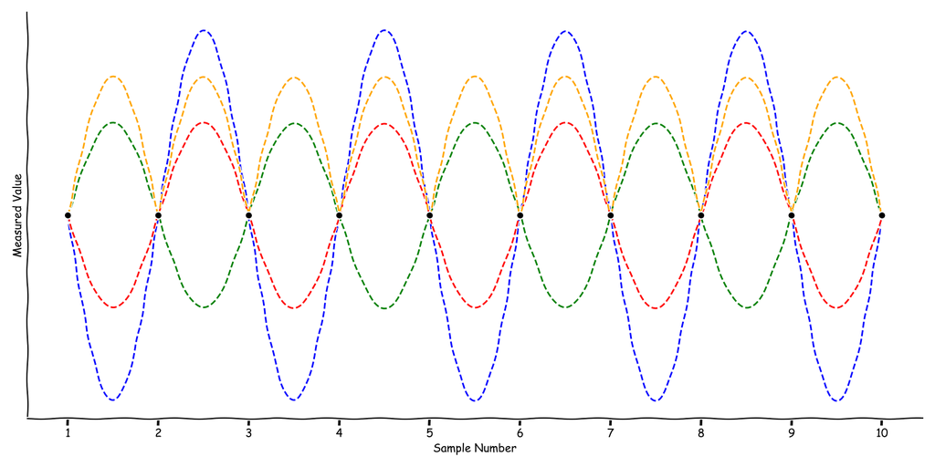

The solid dots represent the data collected from various signals. All of the signals behave differently, but if just the data collected is analyzed, it would appear as if the signal is constant (imagine drawing a line connecting all the data points). This figure shows that it is simply not enough to collect data from a signal at any given sampling rate, but the sampling must be fast enough to capture the important characteristics of a signal. This requirement is a consequence of discrete sampling of a continuous signal. Before choosing a reasonable sampling rate is discussed, it helps to establish a couple of preliminary items first. The sampling rate is usually specified as a frequency in hertz ($ Hz $), often denoted as $ f_s $. A varying time signal may be composed of multiple frequency components. This was shown in Figure 1 of 01.Introduction with the example of sunlight received by the earth. The single-component of a signal with the highest frequency is noted as the maximum signal frequency and is often denoted as $ f_m $. A sampling rate must be greater than twice the maximum signal frequency to reconstruct the original signal from discrete sampling or

$$ f_s \gt 2 f_m $$

This expression comes from the [Nyquist Theorem](https://en.wikipedia.org/wiki/Nyquist%E2%80%93Shannon_sampling_theorem) which is a theorem in the field of digital signal processing. It is important to note two different items about this Nyquist Theorem expression. First, the expression states that the sampling rate must be greater than twice the maximum signal frequency. It is not greater than or equal to maximum signal frequency but simply greater than. If a sampling rate equal to twice the maximum signal frequency is used, then the Nyquist Theorem criterion has not been met, and a proper sampling rate has not been achieved. Second, the Nyquist theorem expression assumes an infinite amount of sampling time. In practice, this is not always possible. A sampling rate much greater than twice the maximum signal frequency must be used to overcome this assumption. If those two criteria ($ \gt 2 f_m $ and infinite sampling time) have been met, then various mathematical techniques may be used to reconstruct the original signal. The term "various mathematical techniques" is used here because there is no one size fits all method for reproducing the original signal. The data collected must be interpreted in the context of the expectation of how the original signal behaves. At times, this reconstruction can be more of an art form than a science but with practice is not all that difficult.

The general procedure for analyzing signals is listed below.

1. Use various filtering techniques to remove any unwanted higher-order frequency components from the original signal.
2. Use a sampling rate according to the Nyquist Theorem expression.
3. The resulting plots may appear to suggest higher-order frequencies. However, if filtering was appropriately conducted, any higher-order frequency greater than the maximum signal frequency may be disregarded.

## Sampling Rate Demonstration

To demonstrate the effects of a selected sampling frequency on a theoretical signal, the 22.Sampling Rate Demonstration.py will be used. Download the script and run it. Initially, what is shown is a sinusoidal signal (the red line) for a time frame of $ 1 s $. Counting the number of times it oscillates in the $ 1 s $ period shows that the signal has a $ 10 Hz $ frequency. This signal will represent an unknown signal that is to be determined by discrete sampling. In practice, this signal will never be known. If it were known, the signal would not need to be sampled. The data acquisition unit (DAQ) line is not yet shown but will be presented as blue markers with lines between them. Various keys may be used to change the DAQ sampling rate. The keys and their effects are listed below.

- `<right arrow>` or `<down arrow>` - Increase the sampling frequency by $ 1 Hz $
- `<left arrow>` or `<up arrow>` - Decrease the sampling frequency by $ 1 Hz $
- `p` or `+` - Increase the sampling frequency by $ 0.1 Hz $
- `m` or `-` - Decrease the sampling frequency by $ 0.1 Hz $

Increasing the sampling frequency shows the behavior of what might be expected from data collected from this $ 10 Hz $ signal. Let's look at several interesting sampling rates.

## Aliasing

Aliases are false frequencies that may appear in data. This type of signal was seen in the previous demonstration. Figure 2 shows the plot from the demonstration when an $ 11 Hz $ sampling rate was used.

Figure 2: Alias Signal

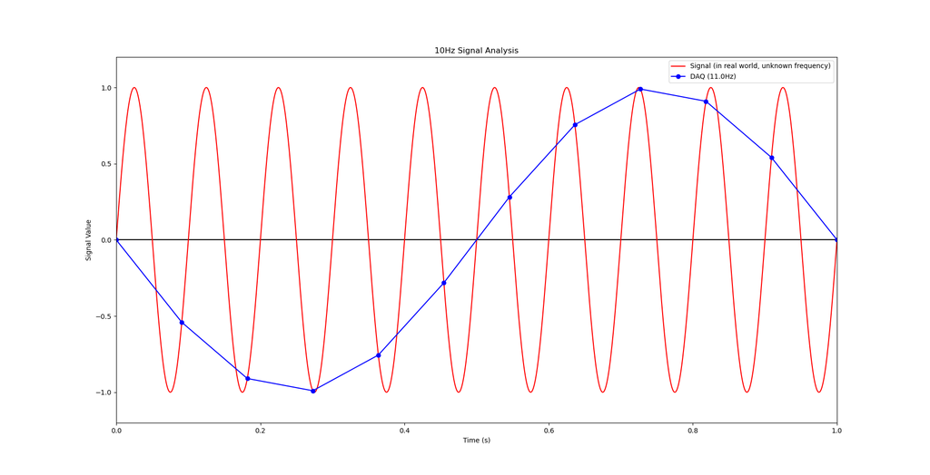

In this situation, the $ 10 Hz $ is being undersampled with a sampling rate of $ 11 Hz $. If taken just at face value, one might think that the signal has a frequency of $ 1 Hz $. However, this signal would be incorrect and is known as an alias. Aliasing occurs with the sampling frequency does not meet the Nyquist Theorem criteria. Sometimes under-sampling cannot be avoided. When the sampling frequency is not high enough, an estimated lowest alias frequency may be made. This estimation is done using a folding diagram, as shown below in Figure 3.

Figure 3: Folding Diagram

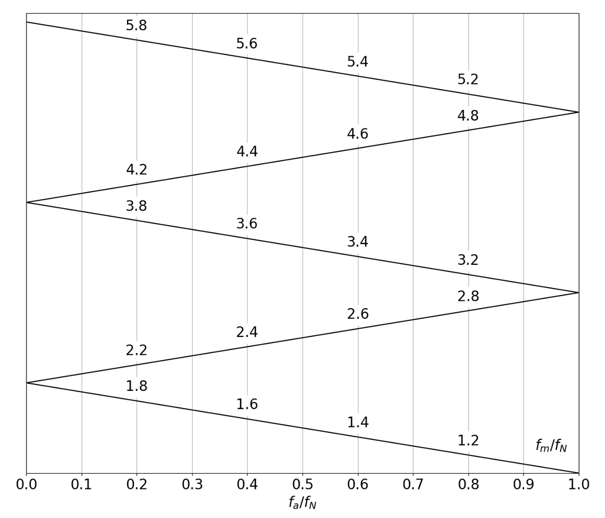

If you have never used a folding diagram before, it may seem a bit overwhelming at first glance. If taken piece by piece, it is straight forward to use. There are four different frequencies referenced in the diagram.

- $ f_a $ - Alias frequency
- $ f_m $ - Maximum signal frequency
- $ f_N $ - Folding frequency, $ f_N = \frac{f_s}{2} $
- $ f_s $ - Sampling frequency

## Aliasing Example

**Given:**

A maximum signal frequency is estimated to be $ 80 Hz $. A sampling frequency of $ 100 Hz $ is used.

**Required:**

Compute the lowest alias frequency using a folding diagram.

**Solution:**

The most challenging part of using a folding diagram is correctly identifying the various frequencies. The maximum signal frequency is

$$ f_m = 80 Hz $$

The sampling frequency is

$$ f_s = 100 Hz $$

Now that those frequencies have been correctly identified, the folding frequency $ f_N $ may be calculated.

$$ f_N = \frac{ f_s }{ 2 } = \frac{100 Hz}{2} = 50 Hz$$

Now the ratio of the maximum signal frequency to the folding frequency may be calculated.

$$ \frac{f_m}{f_N} = \frac{80 Hz}{50 Hz} = 1.6 $$

This ratio is the zig-zag axis shown on the folding diagram. The zig-zag axis may be followed starting at the bottom right corner. The axis is traced until the value of $ 1.6 $ is found. Once the $ 1.6 $ value is found, a line drawn straight down to the bottom axis may be traced to find the value of $ 0.4 $ for the alias frequency ratio to the folding frequency.

$$ 0.4 = \frac{f_a}{f_N} $$

Solving for the alias frequency shows

$$ f_a = 0.4 f_N = 20 Hz $$

This frequency shows that if the $ 80 Hz $ signal is sampled at $ 100 Hz $, the data would indicate a $ 20 Hz $ signal. However, this signal could be disregarded because it has just been shown that it is an alias frequency.